# Installation of Program

> **1. Installation of Anaconda**  
> : https://www.anaconda.com/download/

> **2. Update of PIP**  
> 1) Execution of "Anaconda Prompt" by Administratior  
> 2) pip install --upgrade pip  
> or  
> 2) C:\ProgramData\Anaconda3\python.exe -m pip install --upgrade pip

> **3. Installation of Jupyter Lab**  
> : pip install jupyterlab

> **4. Change Start Location of Jupyter Lab**  
> 1) Right Click the Icon of "Jupyter Notebook"  
> 2) Input the target location (ex. X:) to the end of "대상" and to the "시작 위치"

# Setting of Analysis

> **1. Import Library**

```python
!pip install xgboost
!pip install lightgbm
```

```python
import warnings
warnings.filterwarnings("ignore")
import os
from urllib.request import urlopen
from io import BytesIO
from zipfile import ZipFile
import pandas as pd
pd.options.display.float_format = '{:,.4f}'.format
import statsmodels.api as sm
from scipy import stats
import matplotlib.pyplot as plt
import seaborn as sns
from statsmodels.stats.outliers_influence import variance_inflation_factor
```

# Setting of Analysis

> **1. Import Library**  
> **2. Data Loading** [(Data Source and Description)](https://www.kaggle.com/c/bike-sharing-demand/data)

```python
url_all = 'https://raw.githubusercontent.com/cheonbi/DataScience/master/Time_Series_Analysis_with_Python/Data/all.csv'
raw_all = pd.read_csv(url_all)
raw_all.head()
```

|  | datetime | season | holiday | workingday | weather | temp | atemp | humidity | windspeed | casual | registered | count |
| --- | --- | --- | --- | --- | --- | --- | --- | --- | --- | --- | --- | --- |
| 0 | 2011-01-01 0:00 | 1 | 0 | 0 | 1 | 9.8400 | 14.3950 | 81 | 0.0000 | 3 | 13 | 16 |
| 1 | 2011-01-01 1:00 | 1 | 0 | 0 | 1 | 9.0200 | 13.6350 | 80 | 0.0000 | 8 | 32 | 40 |
| 2 | 2011-01-01 2:00 | 1 | 0 | 0 | 1 | 9.0200 | 13.6350 | 80 | 0.0000 | 5 | 27 | 32 |
| 3 | 2011-01-01 3:00 | 1 | 0 | 0 | 1 | 9.8400 | 14.3950 | 75 | 0.0000 | 3 | 10 | 13 |
| 4 | 2011-01-01 4:00 | 1 | 0 | 0 | 1 | 9.8400 | 14.3950 | 75 | 0.0000 | 0 | 1 | 1 |

[figure not shown]

# Setting of Analysis

> **1. Import Library**  
> **2. Data Loading** [(Data Source and Description)](https://www.kaggle.com/c/bike-sharing-demand/data)  
> **3. Rearrange of Data**

```python
raw_all['temp_group'] = pd.cut(raw_all['temp'], 10)
if 'datetime' in raw_all.columns:
    raw_all['DateTime'] = pd.to_datetime(raw_all['datetime'])
    del raw_all['datetime']
raw_all['Year'] = raw_all.DateTime.dt.year
raw_all['Quater'] = raw_all.DateTime.dt.quarter
raw_all['Quater_ver2'] = raw_all['Quater'] + (raw_all.Year - raw_all.Year.min()) * 4
raw_all['Month'] = raw_all.DateTime.dt.month
raw_all['Day'] = raw_all.DateTime.dt.day
raw_all['Hour'] = raw_all.DateTime.dt.hour
raw_all['DayofWeek'] = raw_all.DateTime.dt.dayofweek
raw_all.info()

if raw_all.index.dtype == 'int64':
    raw_all.set_index('DateTime', inplace=True)
display(raw_all.head())
# bring back
# if raw_all.index.dtype != 'int64':
#     raw_all.reset_index(drop=False, inplace=True)
# display(raw_all.head())
```

```
<class 'pandas.core.frame.DataFrame'>
RangeIndex: 17379 entries, 0 to 17378
Data columns (total 20 columns):
season         17379 non-null int64
holiday        17379 non-null int64
workingday     17379 non-null int64
weather        17379 non-null int64
temp           17379 non-null float64
atemp          17379 non-null float64
humidity       17379 non-null int64
windspeed      17379 non-null float64
casual         17379 non-null int64
registered     17379 non-null int64
count          17379 non-null int64
temp_group     17379 non-null category
DateTime       17379 non-null datetime64[ns]
Year           17379 non-null int64
Quater         17379 non-null int64
Quater_ver2    17379 non-null int64
Month          17379 non-null int64
Day            17379 non-null int64
Hour           17379 non-null int64
DayofWeek      17379 non-null int64
dtypes: category(1), datetime64[ns](1), float64(3), int64(15)
memory usage: 2.5 MB
```

| DateTime | season | holiday | workingday | weather | temp | atemp | humidity | windspeed | casual | registered | count | temp_group | Year | Quater | Quater_ver2 | Month | Day | Hour | DayofWeek |
| --- | --- | --- | --- | --- | --- | --- | --- | --- | --- | --- | --- | --- | --- | --- | --- | --- | --- | --- | --- |
| 2011-01-01 00:00:00 | 1 | 0 | 0 | 1 | 9.8400 | 14.3950 | 81 | 0.0000 | 3 | 13 | 16 | (8.856, 12.874] | 2011 | 1 | 1 | 1 | 1 | 0 | 5 |
| 2011-01-01 01:00:00 | 1 | 0 | 0 | 1 | 9.0200 | 13.6350 | 80 | 0.0000 | 8 | 32 | 40 | (8.856, 12.874] | 2011 | 1 | 1 | 1 | 1 | 1 | 5 |
| 2011-01-01 02:00:00 | 1 | 0 | 0 | 1 | 9.0200 | 13.6350 | 80 | 0.0000 | 5 | 27 | 32 | (8.856, 12.874] | 2011 | 1 | 1 | 1 | 1 | 2 | 5 |
| 2011-01-01 03:00:00 | 1 | 0 | 0 | 1 | 9.8400 | 14.3950 | 75 | 0.0000 | 3 | 10 | 13 | (8.856, 12.874] | 2011 | 1 | 1 | 1 | 1 | 3 | 5 |
| 2011-01-01 04:00:00 | 1 | 0 | 0 | 1 | 9.8400 | 14.3950 | 75 | 0.0000 | 0 | 1 | 1 | (8.856, 12.874] | 2011 | 1 | 1 | 1 | 1 | 4 | 5 |

# Setting of Analysis

> **1. Import Library**  
> **2. Data Loading** [(Data Source and Description)](https://www.kaggle.com/c/bike-sharing-demand/data)  
> **3. Rearrange of Data**  
> **4. Split of Data: Train, Validate, Test Sets**

```python
# Reference: https://towardsdatascience.com/train-test-split-and-cross-validation-in-python-80b61beca4b6
# we usually split our data into two subsets: Training data and Testing data (and sometimes to three: Train, Validata and Test data)
# Overfitting: when the model is too complex (i.e. too many features/variables compared to the number of observation)
# Just Accurate on Training but not on Testing
# Underfitting: when this is usually the result of a very simple model (not enough predictors/independent variables)
# Just not Accurate on Training and Testing

# Setting of X and Y
Y_colname = ['count']
X_remove = ['casual', 'registered']
X_colname = [x for x in raw_all.columns if x not in Y_colname+X_remove]

# if the data is not a time-series
# from sklearn.model_selection import train_test_split
# raw_train, raw_test = train_test_split(raw_all, test_size=0.2, random_state=123)
# print(raw_train.shape, raw_test.shape)

# X_train, X_test, Y_train, Y_test = train_test_split(raw_all[X_colname], raw_all[Y_colname], test_size=0.2, random_state=123)
# print(X_train.shape, Y_train.shape)
# print(X_test.shape, Y_test.shape)

# if the data is a time-series
# raw_train = raw_all.loc[raw_all.Day < 20,:]
# raw_test = raw_all.loc[raw_all.Day >= 20,:]
# print(raw_train.shape, raw_test.shape)
# or
raw_train = raw_all.loc[raw_all.index < '2012-07-01',:]
raw_test = raw_all.loc[raw_all.index >= '2012-07-01',:]
print(raw_train.shape, raw_test.shape)

Y_train = raw_train[Y_colname]
X_train = raw_train[X_colname]
Y_test = raw_test[Y_colname]
X_test = raw_test[X_colname]
print(X_train.shape, Y_train.shape)
print(X_test.shape, Y_test.shape)
```

```
(13003, 19) (4376, 19)
(13003, 16) (13003, 1)
(4376, 16) (4376, 1)
```

# Setting of Analysis

> **1. Import Library**  
> **2. Data Loading** [(Data Source and Description)](https://www.kaggle.com/c/bike-sharing-demand/data)  
> **3. Rearrange of Data**  
> **4. Split of Data: Train, Validate, Test Sets**  
> **5. Descriptive Statistics and Getting Insight from Features**

```
<class 'pandas.core.frame.DataFrame'>
DatetimeIndex: 13003 entries, 2011-01-01 00:00:00 to 2012-06-30 23:00:00
Data columns (total 19 columns):
season         13003 non-null int64
holiday        13003 non-null int64
workingday     13003 non-null int64
weather        13003 non-null int64
temp           13003 non-null float64
atemp          13003 non-null float64
humidity       13003 non-null int64
windspeed      13003 non-null float64
casual         13003 non-null int64
registered     13003 non-null int64
count          13003 non-null int64
temp_group     13003 non-null category
Year           13003 non-null int64
Quater         13003 non-null int64
Quater_ver2    13003 non-null int64
Month          13003 non-null int64
Day            13003 non-null int64
Hour           13003 non-null int64
DayofWeek      13003 non-null int64
dtypes: category(1), float64(3), int64(15)
memory usage: 1.9 MB
```

|  | 0 | count | unique | top | freq | mean | std | min | 25% | 50% | 75% | max |
| --- | --- | --- | --- | --- | --- | --- | --- | --- | --- | --- | --- | --- |
| season | int64 | 13,003.0000 | NaN | NaN | NaN | 2.2129 | 1.0526 | 1.0000 | 1.0000 | 2.0000 | 3.0000 | 4.0000 |
| holiday | int64 | 13,003.0000 | NaN | NaN | NaN | 0.0275 | 0.1634 | 0.0000 | 0.0000 | 0.0000 | 0.0000 | 1.0000 |
| workingday | int64 | 13,003.0000 | NaN | NaN | NaN | 0.6848 | 0.4646 | 0.0000 | 0.0000 | 1.0000 | 1.0000 | 1.0000 |
| weather | int64 | 13,003.0000 | NaN | NaN | NaN | 1.4263 | 0.6478 | 1.0000 | 1.0000 | 1.0000 | 2.0000 | 4.0000 |
| temp | float64 | 13,003.0000 | NaN | NaN | NaN | 19.7464 | 7.8402 | 0.8200 | 13.1200 | 19.6800 | 26.2400 | 40.1800 |
| atemp | float64 | 13,003.0000 | NaN | NaN | NaN | 23.1328 | 8.5606 | 0.0000 | 15.9100 | 23.4850 | 30.3050 | 50.0000 |
| humidity | int64 | 13,003.0000 | NaN | NaN | NaN | 62.3524 | 19.9774 | 0.0000 | 47.0000 | 62.0000 | 79.0000 | 100.0000 |
| windspeed | float64 | 13,003.0000 | NaN | NaN | NaN | 13.1376 | 8.3228 | 0.0000 | 7.0015 | 12.9980 | 19.0012 | 56.9969 |
| casual | int64 | 13,003.0000 | NaN | NaN | NaN | 32.4960 | 46.6595 | 0.0000 | 3.0000 | 14.0000 | 42.0000 | 367.0000 |
| registered | int64 | 13,003.0000 | NaN | NaN | NaN | 135.2175 | 131.9019 | 0.0000 | 30.0000 | 103.0000 | 194.0000 | 796.0000 |
| count | int64 | 13,003.0000 | NaN | NaN | NaN | 167.7135 | 160.7855 | 1.0000 | 35.0000 | 124.0000 | 246.0000 | 957.0000 |
| temp_group | category | 13003 | 10 | (24.928, 28.946] | 2208 | NaN | NaN | NaN | NaN | NaN | NaN | NaN |
| Year | int64 | 13,003.0000 | NaN | NaN | NaN | 2,011.3352 | 0.4721 | 2,011.0000 | 2,011.0000 | 2,011.0000 | 2,012.0000 | 2,012.0000 |
| Quater | int64 | 13,003.0000 | NaN | NaN | NaN | 2.1811 | 1.0676 | 1.0000 | 1.0000 | 2.0000 | 3.0000 | 4.0000 |
| Quater_ver2 | int64 | 13,003.0000 | NaN | NaN | NaN | 3.5217 | 1.6973 | 1.0000 | 2.0000 | 4.0000 | 5.0000 | 6.0000 |
| Month | int64 | 13,003.0000 | NaN | NaN | NaN | 5.5447 | 3.3005 | 1.0000 | 3.0000 | 5.0000 | 8.0000 | 12.0000 |
| Day | int64 | 13,003.0000 | NaN | NaN | NaN | 15.6709 | 8.7845 | 1.0000 | 8.0000 | 16.0000 | 23.0000 | 31.0000 |
| Hour | int64 | 13,003.0000 | NaN | NaN | NaN | 11.5553 | 6.9115 | 0.0000 | 6.0000 | 12.0000 | 18.0000 | 23.0000 |
| DayofWeek | int64 | 13,003.0000 | NaN | NaN | NaN | 3.0076 | 2.0002 | 0.0000 | 1.0000 | 3.0000 | 5.0000 | 6.0000 |

```
(0, 1000)
```

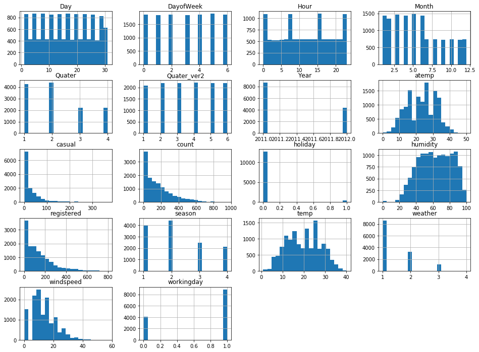

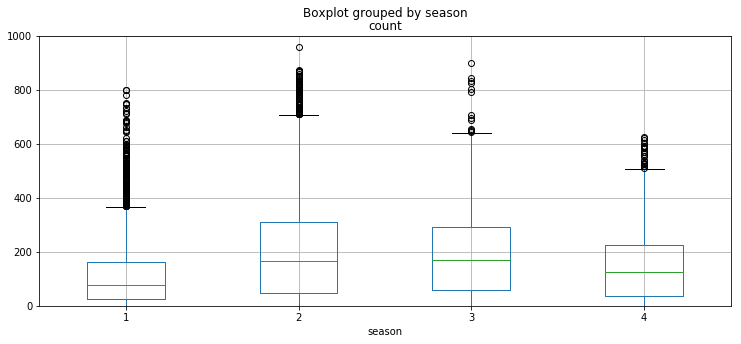

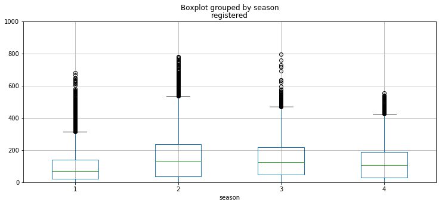

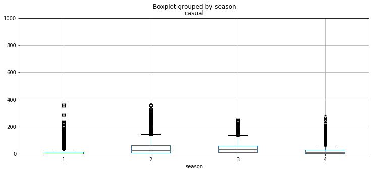

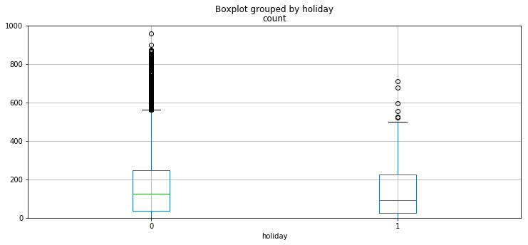

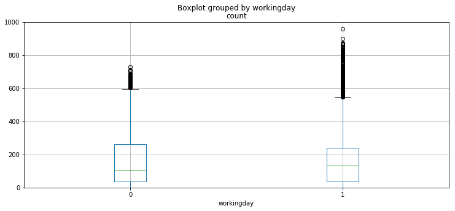

```python
raw_train.shape
raw_train.head()
raw_train.tail()
raw_train.isnull()
raw_train.isnull().sum()
raw_train.isnull().describe()
raw_train.info()
raw_train.dtypes
raw_train.describe()
raw_train.describe().T
raw_train.describe(include='all').T
display(pd.concat([raw_train.dtypes, raw_train.describe(include='all').T], axis=1))
raw_train.hist(bins=20, grid=True, figsize=(16,12))

raw_train.boxplot(column='count', by='season', grid=True, figsize=(12,5))
plt.ylim(0,1000)
raw_train.boxplot(column='registered', by='season', grid=True, figsize=(12,5))
plt.ylim(0,1000)
raw_train.boxplot(column='casual', by='season', grid=True, figsize=(12,5))
plt.ylim(0,1000)

raw_train.boxplot(column='count', by='holiday', grid=True, figsize=(12,5))
plt.ylim(0,1000)
raw_train.boxplot(column='count', by='workingday', grid=True, figsize=(12,5))
plt.ylim(0,1000)
```

```
(0, 1000)
```

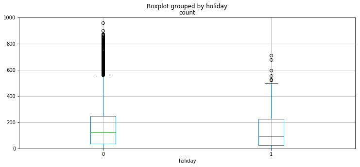

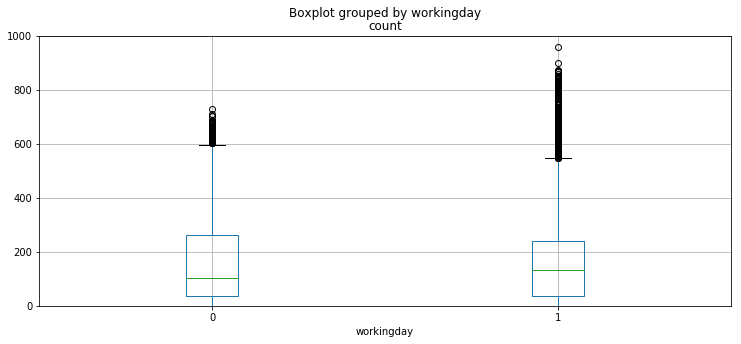

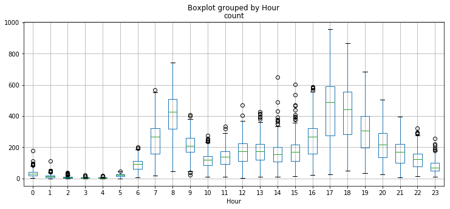

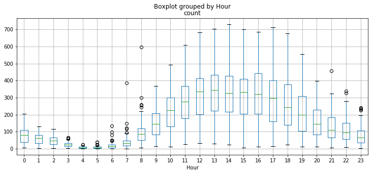

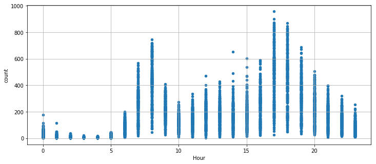

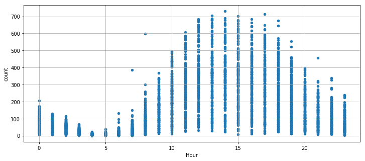

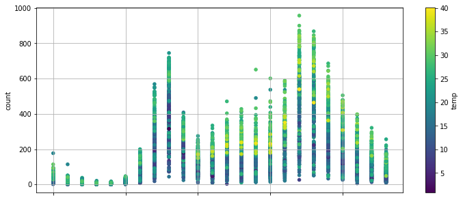

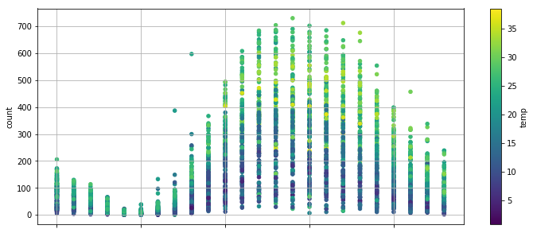

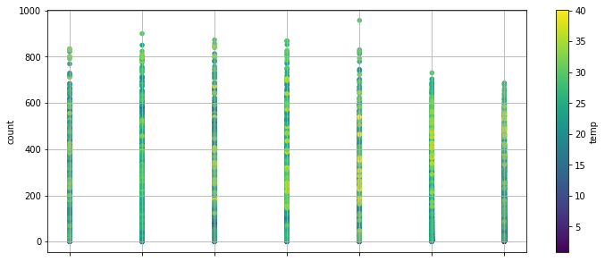

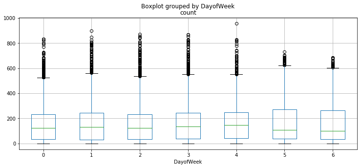

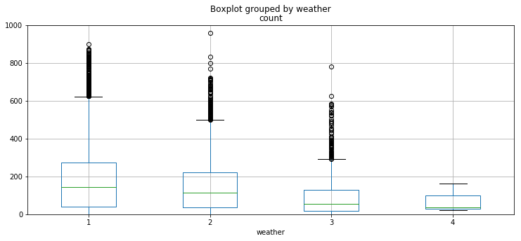

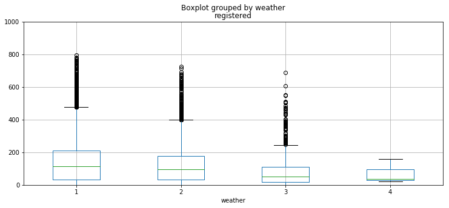

[1 more figures not shown]

```python
raw_train.boxplot(column='count', by='holiday', grid=True, figsize=(12,5))
plt.ylim(0,1000)
raw_train.boxplot(column='count', by='workingday', grid=True, figsize=(12,5))
plt.ylim(0,1000)
raw_train[raw_train.workingday == 1]
raw_train[raw_train.workingday == 1].boxplot(column='count', by='Hour', grid=True, figsize=(12,5))
raw_train[raw_train.workingday == 0].boxplot(column='count', by='Hour', grid=True, figsize=(12,5))
raw_train[raw_train.workingday == 1].plot.scatter(y='count', x='Hour', grid=True, figsize=(12,5))
raw_train[raw_train.workingday == 0].plot.scatter(y='count', x='Hour', grid=True, figsize=(12,5))
raw_train[raw_train.workingday == 1].plot.scatter(y='count', x='Hour', c='temp', grid=True, figsize=(12,5), colormap='viridis')
raw_train[raw_train.workingday == 0].plot.scatter(y='count', x='Hour', c='temp', grid=True, figsize=(12,5), colormap='viridis')

raw_train.plot.scatter(y='count', x='DayofWeek', c='temp', grid=True, figsize=(12,5), colormap='viridis')
raw_train.boxplot(column='count', by='DayofWeek', grid=True, figsize=(12,5))

raw_train.boxplot(column='count', by='weather', grid=True, figsize=(12,5))
plt.ylim(0,1000)
raw_train.boxplot(column='registered', by='weather', grid=True, figsize=(12,5))
plt.ylim(0,1000)
raw_train.boxplot(column='casual', by='weather', grid=True, figsize=(12,5))
plt.ylim(0,1000)
```

|  | 1 | 2 | 3 | 4 |
| --- | --- | --- | --- | --- |
| weather | 66.1001 | 25.1942 | 8.6826 | 0.0231 |

| weather count | 1 | 2 | 3 | 4 | All |
| --- | --- | --- | --- | --- | --- |
| 1 | 89 | 36 | 24 | 0 | 149 |
| 2 | 116 | 45 | 29 | 0 | 190 |
| 3 | 111 | 49 | 33 | 0 | 193 |
| 4 | 126 | 52 | 21 | 0 | 199 |
| 5 | 131 | 45 | 26 | 0 | 202 |
| 6 | 120 | 52 | 13 | 0 | 185 |
| 7 | 99 | 35 | 15 | 0 | 149 |
| 8 | 88 | 30 | 18 | 0 | 136 |
| 9 | 53 | 26 | 9 | 0 | 88 |
| 10 | 81 | 22 | 8 | 0 | 111 |
| 11 | 60 | 23 | 14 | 0 | 97 |
| 12 | 53 | 26 | 11 | 0 | 90 |
| 13 | 50 | 20 | 13 | 0 | 83 |
| 14 | 48 | 18 | 11 | 0 | 77 |
| 15 | 45 | 13 | 7 | 0 | 65 |
| 16 | 48 | 23 | 7 | 0 | 78 |
| 17 | 43 | 29 | 11 | 0 | 83 |
| 18 | 39 | 15 | 8 | 0 | 62 |
| 19 | 31 | 8 | 9 | 0 | 48 |
| 20 | 38 | 24 | 11 | 0 | 73 |
| 21 | 37 | 24 | 8 | 0 | 69 |
| 22 | 37 | 12 | 9 | 0 | 58 |
| 23 | 45 | 16 | 5 | 1 | 67 |
| 24 | 39 | 14 | 16 | 0 | 69 |
| 25 | 35 | 19 | 7 | 0 | 61 |
| 26 | 47 | 15 | 11 | 0 | 73 |
| 27 | 39 | 13 | 7 | 0 | 59 |
| 28 | 42 | 20 | 7 | 0 | 69 |
| 29 | 33 | 5 | 11 | 0 | 49 |
| 30 | 38 | 11 | 8 | 0 | 57 |
| ... | ... | ... | ... | ... | ... |
| 798 | 1 | 0 | 0 | 0 | 1 |
| 800 | 1 | 1 | 0 | 0 | 2 |
| 801 | 3 | 0 | 0 | 0 | 3 |
| 804 | 1 | 0 | 0 | 0 | 1 |
| 810 | 1 | 0 | 0 | 0 | 1 |
| 811 | 1 | 0 | 0 | 0 | 1 |
| 812 | 1 | 0 | 0 | 0 | 1 |
| 813 | 2 | 0 | 0 | 0 | 2 |
| 819 | 1 | 0 | 0 | 0 | 1 |
| 822 | 2 | 0 | 0 | 0 | 2 |
| 823 | 2 | 0 | 0 | 0 | 2 |
| 824 | 1 | 0 | 0 | 0 | 1 |
| 827 | 1 | 0 | 0 | 0 | 1 |
| 830 | 1 | 0 | 0 | 0 | 1 |
| 831 | 0 | 1 | 0 | 0 | 1 |
| 833 | 1 | 0 | 0 | 0 | 1 |
| 834 | 1 | 0 | 0 | 0 | 1 |
| 839 | 1 | 0 | 0 | 0 | 1 |
| 843 | 1 | 0 | 0 | 0 | 1 |
| 846 | 1 | 0 | 0 | 0 | 1 |
| 850 | 1 | 0 | 0 | 0 | 1 |
| 852 | 1 | 0 | 0 | 0 | 1 |
| 857 | 1 | 0 | 0 | 0 | 1 |
| 867 | 1 | 0 | 0 | 0 | 1 |
| 868 | 1 | 0 | 0 | 0 | 1 |
| 869 | 1 | 0 | 0 | 0 | 1 |
| 873 | 1 | 0 | 0 | 0 | 1 |
| 900 | 1 | 0 | 0 | 0 | 1 |
| 957 | 0 | 1 | 0 | 0 | 1 |
| All | 8595 | 3276 | 1129 | 3 | 13003 |

753 rows × 5 columns

| weather count | 1 | 2 | 3 | 4 | All |
| --- | --- | --- | --- | --- | --- |
| 1 | 1.0355 | 1.0989 | 2.1258 | 0.0000 | 1.1459 |
| 2 | 1.3496 | 1.3736 | 2.5686 | 0.0000 | 1.4612 |
| 3 | 1.2914 | 1.4957 | 2.9229 | 0.0000 | 1.4843 |
| 4 | 1.4660 | 1.5873 | 1.8601 | 0.0000 | 1.5304 |
| 5 | 1.5241 | 1.3736 | 2.3029 | 0.0000 | 1.5535 |
| 6 | 1.3962 | 1.5873 | 1.1515 | 0.0000 | 1.4227 |
| 7 | 1.1518 | 1.0684 | 1.3286 | 0.0000 | 1.1459 |
| 8 | 1.0239 | 0.9158 | 1.5943 | 0.0000 | 1.0459 |
| 9 | 0.6166 | 0.7937 | 0.7972 | 0.0000 | 0.6768 |
| 10 | 0.9424 | 0.6716 | 0.7086 | 0.0000 | 0.8536 |
| 11 | 0.6981 | 0.7021 | 1.2400 | 0.0000 | 0.7460 |
| 12 | 0.6166 | 0.7937 | 0.9743 | 0.0000 | 0.6921 |
| 13 | 0.5817 | 0.6105 | 1.1515 | 0.0000 | 0.6383 |
| 14 | 0.5585 | 0.5495 | 0.9743 | 0.0000 | 0.5922 |
| 15 | 0.5236 | 0.3968 | 0.6200 | 0.0000 | 0.4999 |
| 16 | 0.5585 | 0.7021 | 0.6200 | 0.0000 | 0.5999 |
| 17 | 0.5003 | 0.8852 | 0.9743 | 0.0000 | 0.6383 |
| 18 | 0.4538 | 0.4579 | 0.7086 | 0.0000 | 0.4768 |
| 19 | 0.3607 | 0.2442 | 0.7972 | 0.0000 | 0.3691 |
| 20 | 0.4421 | 0.7326 | 0.9743 | 0.0000 | 0.5614 |
| 21 | 0.4305 | 0.7326 | 0.7086 | 0.0000 | 0.5306 |
| 22 | 0.4305 | 0.3663 | 0.7972 | 0.0000 | 0.4461 |
| 23 | 0.5236 | 0.4884 | 0.4429 | 33.3333 | 0.5153 |
| 24 | 0.4538 | 0.4274 | 1.4172 | 0.0000 | 0.5306 |
| 25 | 0.4072 | 0.5800 | 0.6200 | 0.0000 | 0.4691 |
| 26 | 0.5468 | 0.4579 | 0.9743 | 0.0000 | 0.5614 |
| 27 | 0.4538 | 0.3968 | 0.6200 | 0.0000 | 0.4537 |
| 28 | 0.4887 | 0.6105 | 0.6200 | 0.0000 | 0.5306 |
| 29 | 0.3839 | 0.1526 | 0.9743 | 0.0000 | 0.3768 |
| 30 | 0.4421 | 0.3358 | 0.7086 | 0.0000 | 0.4384 |
| ... | ... | ... | ... | ... | ... |
| 798 | 0.0116 | 0.0000 | 0.0000 | 0.0000 | 0.0077 |
| 800 | 0.0116 | 0.0305 | 0.0000 | 0.0000 | 0.0154 |
| 801 | 0.0349 | 0.0000 | 0.0000 | 0.0000 | 0.0231 |
| 804 | 0.0116 | 0.0000 | 0.0000 | 0.0000 | 0.0077 |
| 810 | 0.0116 | 0.0000 | 0.0000 | 0.0000 | 0.0077 |
| 811 | 0.0116 | 0.0000 | 0.0000 | 0.0000 | 0.0077 |
| 812 | 0.0116 | 0.0000 | 0.0000 | 0.0000 | 0.0077 |
| 813 | 0.0233 | 0.0000 | 0.0000 | 0.0000 | 0.0154 |
| 819 | 0.0116 | 0.0000 | 0.0000 | 0.0000 | 0.0077 |
| 822 | 0.0233 | 0.0000 | 0.0000 | 0.0000 | 0.0154 |
| 823 | 0.0233 | 0.0000 | 0.0000 | 0.0000 | 0.0154 |
| 824 | 0.0116 | 0.0000 | 0.0000 | 0.0000 | 0.0077 |
| 827 | 0.0116 | 0.0000 | 0.0000 | 0.0000 | 0.0077 |
| 830 | 0.0116 | 0.0000 | 0.0000 | 0.0000 | 0.0077 |
| 831 | 0.0000 | 0.0305 | 0.0000 | 0.0000 | 0.0077 |
| 833 | 0.0116 | 0.0000 | 0.0000 | 0.0000 | 0.0077 |
| 834 | 0.0116 | 0.0000 | 0.0000 | 0.0000 | 0.0077 |
| 839 | 0.0116 | 0.0000 | 0.0000 | 0.0000 | 0.0077 |
| 843 | 0.0116 | 0.0000 | 0.0000 | 0.0000 | 0.0077 |
| 846 | 0.0116 | 0.0000 | 0.0000 | 0.0000 | 0.0077 |
| 850 | 0.0116 | 0.0000 | 0.0000 | 0.0000 | 0.0077 |
| 852 | 0.0116 | 0.0000 | 0.0000 | 0.0000 | 0.0077 |
| 857 | 0.0116 | 0.0000 | 0.0000 | 0.0000 | 0.0077 |
| 867 | 0.0116 | 0.0000 | 0.0000 | 0.0000 | 0.0077 |
| 868 | 0.0116 | 0.0000 | 0.0000 | 0.0000 | 0.0077 |
| 869 | 0.0116 | 0.0000 | 0.0000 | 0.0000 | 0.0077 |
| 873 | 0.0116 | 0.0000 | 0.0000 | 0.0000 | 0.0077 |
| 900 | 0.0116 | 0.0000 | 0.0000 | 0.0000 | 0.0077 |
| 957 | 0.0000 | 0.0305 | 0.0000 | 0.0000 | 0.0077 |
| All | 100.0000 | 100.0000 | 100.0000 | 100.0000 | 100.0000 |

753 rows × 5 columns

|  | weather | 1 | 2 | 3 | 4 |
| --- | --- | --- | --- | --- | --- |
| Day | count | 8,595.0000 | 3,276.0000 | 1,129.0000 | 3.0000 |
|  | mean | 15.6625 | 15.6966 | 15.6528 | 18.6667 |
|  | std | 8.8893 | 8.5156 | 8.7605 | 8.7369 |
|  | min | 1.0000 | 1.0000 | 1.0000 | 9.0000 |
|  | 25% | 8.0000 | 8.0000 | 8.0000 | 15.0000 |
|  | 50% | 15.0000 | 16.0000 | 16.0000 | 21.0000 |
|  | 75% | 24.0000 | 23.0000 | 23.0000 | 23.5000 |
|  | max | 31.0000 | 31.0000 | 31.0000 | 26.0000 |
| DayofWeek | count | 8,595.0000 | 3,276.0000 | 1,129.0000 | 3.0000 |
|  | mean | 3.0816 | 2.8712 | 2.8423 | 2.3333 |
|  | std | 2.0164 | 1.9994 | 1.8431 | 2.5166 |
|  | min | 0.0000 | 0.0000 | 0.0000 | 0.0000 |
|  | 25% | 1.0000 | 1.0000 | 1.0000 | 1.0000 |
|  | 50% | 3.0000 | 3.0000 | 3.0000 | 2.0000 |
|  | 75% | 5.0000 | 5.0000 | 4.0000 | 3.5000 |
|  | max | 6.0000 | 6.0000 | 6.0000 | 5.0000 |
| Hour | count | 8,595.0000 | 3,276.0000 | 1,129.0000 | 3.0000 |
|  | mean | 11.7536 | 10.9841 | 11.7033 | 11.6667 |
|  | std | 7.0188 | 6.6192 | 6.8302 | 9.2916 |
|  | min | 0.0000 | 0.0000 | 0.0000 | 1.0000 |
|  | 25% | 6.0000 | 6.0000 | 6.0000 | 8.5000 |
|  | 50% | 12.0000 | 11.0000 | 12.0000 | 16.0000 |
|  | 75% | 18.0000 | 16.0000 | 18.0000 | 17.0000 |
|  | max | 23.0000 | 23.0000 | 23.0000 | 18.0000 |
| Month | count | 8,595.0000 | 3,276.0000 | 1,129.0000 | 3.0000 |
|  | mean | 5.6043 | 5.3446 | 5.6838 | 1.0000 |
|  | std | 3.2455 | 3.3833 | 3.4446 | 0.0000 |
|  | min | 1.0000 | 1.0000 | 1.0000 | 1.0000 |
|  | 25% | 3.0000 | 3.0000 | 3.0000 | 1.0000 |
|  | 50% | 5.0000 | 5.0000 | 5.0000 | 1.0000 |
| ... | ... | ... | ... | ... | ... |
| season | std | 1.0425 | 1.0603 | 1.0980 | 0.0000 |
|  | min | 1.0000 | 1.0000 | 1.0000 | 1.0000 |
|  | 25% | 1.0000 | 1.0000 | 1.0000 | 1.0000 |
|  | 50% | 2.0000 | 2.0000 | 2.0000 | 1.0000 |
|  | 75% | 3.0000 | 3.0000 | 3.0000 | 1.0000 |
|  | max | 4.0000 | 4.0000 | 4.0000 | 1.0000 |
| temp | count | 8,595.0000 | 3,276.0000 | 1,129.0000 | 3.0000 |
|  | mean | 20.2563 | 18.9676 | 18.1562 | 7.6533 |
|  | std | 8.2237 | 7.0881 | 6.3819 | 1.7070 |
|  | min | 0.8200 | 0.8200 | 3.2800 | 5.7400 |
|  | 25% | 13.1200 | 13.1200 | 13.9400 | 6.9700 |
|  | 50% | 20.5000 | 18.8600 | 18.0400 | 8.2000 |
|  | 75% | 27.0600 | 24.6000 | 22.9600 | 8.6100 |
|  | max | 40.1800 | 37.7200 | 36.9000 | 9.0200 |
| windspeed | count | 8,595.0000 | 3,276.0000 | 1,129.0000 | 3.0000 |
|  | mean | 13.2494 | 12.3175 | 14.6645 | 13.6680 |
|  | std | 8.4506 | 7.6910 | 8.8388 | 8.0208 |
|  | min | 0.0000 | 0.0000 | 0.0000 | 6.0032 |
|  | 25% | 7.0015 | 7.0015 | 8.9981 | 9.5006 |
|  | 50% | 12.9980 | 11.0014 | 12.9980 | 12.9980 |
|  | 75% | 19.0012 | 16.9979 | 19.9995 | 17.5004 |
|  | max | 54.0020 | 47.9988 | 56.9969 | 22.0028 |
| workingday | count | 8,595.0000 | 3,276.0000 | 1,129.0000 | 3.0000 |
|  | mean | 0.6689 | 0.7042 | 0.7493 | 0.6667 |
|  | std | 0.4706 | 0.4565 | 0.4336 | 0.5774 |
|  | min | 0.0000 | 0.0000 | 0.0000 | 0.0000 |
|  | 25% | 0.0000 | 0.0000 | 0.0000 | 0.5000 |
|  | 50% | 1.0000 | 1.0000 | 1.0000 | 1.0000 |
|  | 75% | 1.0000 | 1.0000 | 1.0000 | 1.0000 |
|  | max | 1.0000 | 1.0000 | 1.0000 | 1.0000 |

136 rows × 4 columns

| weather | DayofWeek | Day count | Day mean | Day std | Day min | Day 25% | Day 50% | Day 75% | Day max | Hour count | Hour mean | ... | windspeed 75% | windspeed max | workingday count | workingday mean | workingday std | workingday min | workingday 25% | workingday 50% | workingday 75% | workingday max |
| --- | --- | --- | --- | --- | --- | --- | --- | --- | --- | --- | --- | --- | --- | --- | --- | --- | --- | --- | --- | --- | --- | --- |
| 1 | 0 | 1,211.0000 | 15.5962 | 8.8439 | 1.0000 | 8.0000 | 14.0000 | 24.0000 | 31.0000 | 1,211.0000 | 11.4203 | ... | 19.0012 | 47.9988 | 1,211.0000 | 0.8514 | 0.3559 | 0.0000 | 1.0000 | 1.0000 | 1.0000 | 1.0000 |
|  | 1 | 1,163.0000 | 16.0507 | 9.3290 | 1.0000 | 8.0000 | 16.0000 | 25.0000 | 31.0000 | 1,163.0000 | 12.2451 | ... | 19.0012 | 51.9987 | 1,163.0000 | 1.0000 | 0.0000 | 1.0000 | 1.0000 | 1.0000 | 1.0000 | 1.0000 |
|  | 2 | 1,138.0000 | 15.7127 | 8.9799 | 1.0000 | 8.0000 | 15.0000 | 24.0000 | 31.0000 | 1,138.0000 | 11.5800 | ... | 19.0012 | 39.0007 | 1,138.0000 | 1.0000 | 0.0000 | 1.0000 | 1.0000 | 1.0000 | 1.0000 | 1.0000 |
|  | 3 | 1,213.0000 | 14.7716 | 9.0324 | 1.0000 | 7.0000 | 14.0000 | 22.0000 | 31.0000 | 1,213.0000 | 12.0725 | ... | 19.0012 | 46.0022 | 1,213.0000 | 0.9802 | 0.1393 | 0.0000 | 1.0000 | 1.0000 | 1.0000 | 1.0000 |
|  | 4 | 1,270.0000 | 15.4520 | 8.6936 | 1.0000 | 8.0000 | 15.0000 | 23.0000 | 30.0000 | 1,270.0000 | 11.5819 | ... | 19.0012 | 54.0020 | 1,270.0000 | 0.9669 | 0.1789 | 0.0000 | 1.0000 | 1.0000 | 1.0000 | 1.0000 |
|  | 5 | 1,272.0000 | 15.9607 | 8.7323 | 1.0000 | 9.0000 | 16.0000 | 23.0000 | 31.0000 | 1,272.0000 | 11.3789 | ... | 16.9979 | 50.0021 | 1,272.0000 | 0.0000 | 0.0000 | 0.0000 | 0.0000 | 0.0000 | 0.0000 | 0.0000 |
|  | 6 | 1,328.0000 | 16.0693 | 8.6109 | 1.0000 | 9.0000 | 16.0000 | 24.0000 | 31.0000 | 1,328.0000 | 12.0075 | ... | 19.0012 | 43.0006 | 1,328.0000 | 0.0000 | 0.0000 | 0.0000 | 0.0000 | 0.0000 | 0.0000 | 0.0000 |
| 2 | 0 | 519.0000 | 16.8112 | 8.6840 | 2.0000 | 9.0000 | 18.0000 | 23.0000 | 31.0000 | 519.0000 | 11.9094 | ... | 16.9979 | 39.0007 | 519.0000 | 0.8285 | 0.3773 | 0.0000 | 1.0000 | 1.0000 | 1.0000 | 1.0000 |
|  | 1 | 510.0000 | 14.5588 | 7.7819 | 1.0000 | 8.0000 | 15.0000 | 20.0000 | 31.0000 | 510.0000 | 10.3804 | ... | 16.9979 | 40.9973 | 510.0000 | 1.0000 | 0.0000 | 1.0000 | 1.0000 | 1.0000 | 1.0000 | 1.0000 |
|  | 2 | 446.0000 | 16.1996 | 8.3772 | 1.0000 | 9.0000 | 16.0000 | 22.0000 | 30.0000 | 446.0000 | 11.1054 | ... | 16.9979 | 39.0007 | 446.0000 | 1.0000 | 0.0000 | 1.0000 | 1.0000 | 1.0000 | 1.0000 | 1.0000 |
|  | 3 | 484.0000 | 17.3120 | 7.8545 | 1.0000 | 10.0000 | 19.0000 | 24.0000 | 31.0000 | 484.0000 | 10.5351 | ... | 19.0012 | 43.0006 | 484.0000 | 1.0000 | 0.0000 | 1.0000 | 1.0000 | 1.0000 | 1.0000 | 1.0000 |
|  | 4 | 443.0000 | 15.2777 | 8.8006 | 1.0000 | 8.0000 | 16.0000 | 23.0000 | 30.0000 | 443.0000 | 11.3454 | ... | 16.9979 | 36.9974 | 443.0000 | 0.9865 | 0.1157 | 0.0000 | 1.0000 | 1.0000 | 1.0000 | 1.0000 |
|  | 5 | 464.0000 | 15.6401 | 8.9146 | 1.0000 | 8.0000 | 16.0000 | 24.0000 | 31.0000 | 464.0000 | 11.6767 | ... | 16.9979 | 43.9989 | 464.0000 | 0.0000 | 0.0000 | 0.0000 | 0.0000 | 0.0000 | 0.0000 | 0.0000 |
|  | 6 | 410.0000 | 13.7634 | 8.7413 | 1.0000 | 5.0000 | 14.5000 | 20.0000 | 30.0000 | 410.0000 | 9.7878 | ... | 16.9979 | 47.9988 | 410.0000 | 0.0000 | 0.0000 | 0.0000 | 0.0000 | 0.0000 | 0.0000 | 0.0000 |
| 3 | 0 | 124.0000 | 18.4194 | 7.1898 | 2.0000 | 14.7500 | 21.0000 | 23.0000 | 31.0000 | 124.0000 | 11.6774 | ... | 19.9995 | 43.9989 | 124.0000 | 0.8710 | 0.3366 | 0.0000 | 1.0000 | 1.0000 | 1.0000 | 1.0000 |
|  | 1 | 170.0000 | 15.2000 | 8.1477 | 1.0000 | 6.0000 | 15.0000 | 22.0000 | 29.0000 | 170.0000 | 11.0529 | ... | 19.9995 | 39.0007 | 170.0000 | 1.0000 | 0.0000 | 1.0000 | 1.0000 | 1.0000 | 1.0000 | 1.0000 |
|  | 2 | 266.0000 | 14.9699 | 8.5132 | 1.0000 | 7.0000 | 13.0000 | 23.0000 | 30.0000 | 266.0000 | 12.0564 | ... | 19.0012 | 43.0006 | 266.0000 | 1.0000 | 0.0000 | 1.0000 | 1.0000 | 1.0000 | 1.0000 | 1.0000 |
|  | 3 | 152.0000 | 16.1579 | 8.6485 | 1.0000 | 10.0000 | 15.5000 | 24.0000 | 31.0000 | 152.0000 | 10.8026 | ... | 16.9979 | 40.9973 | 152.0000 | 1.0000 | 0.0000 | 1.0000 | 1.0000 | 1.0000 | 1.0000 | 1.0000 |
|  | 4 | 150.0000 | 15.9933 | 9.2631 | 1.0000 | 8.0000 | 19.0000 | 23.0000 | 30.0000 | 150.0000 | 11.7267 | ... | 18.5004 | 40.9973 | 150.0000 | 1.0000 | 0.0000 | 1.0000 | 1.0000 | 1.0000 | 1.0000 | 1.0000 |
|  | 5 | 151.0000 | 15.2517 | 9.8199 | 1.0000 | 5.0000 | 14.0000 | 24.0000 | 31.0000 | 151.0000 | 11.7748 | ... | 22.0028 | 55.9986 | 151.0000 | 0.0000 | 0.0000 | 0.0000 | 0.0000 | 0.0000 | 0.0000 | 0.0000 |
|  | 6 | 116.0000 | 14.3448 | 9.2578 | 1.0000 | 6.0000 | 14.5000 | 22.0000 | 29.0000 | 116.0000 | 12.9310 | ... | 23.9994 | 56.9969 | 116.0000 | 0.0000 | 0.0000 | 0.0000 | 0.0000 | 0.0000 | 0.0000 | 0.0000 |
| 4 | 0 | 1.0000 | 9.0000 | nan | 9.0000 | 9.0000 | 9.0000 | 9.0000 | 9.0000 | 1.0000 | 18.0000 | ... | 6.0032 | 6.0032 | 1.0000 | 1.0000 | nan | 1.0000 | 1.0000 | 1.0000 | 1.0000 | 1.0000 |
|  | 2 | 1.0000 | 26.0000 | nan | 26.0000 | 26.0000 | 26.0000 | 26.0000 | 26.0000 | 1.0000 | 16.0000 | ... | 22.0028 | 22.0028 | 1.0000 | 1.0000 | nan | 1.0000 | 1.0000 | 1.0000 | 1.0000 | 1.0000 |
|  | 5 | 1.0000 | 21.0000 | nan | 21.0000 | 21.0000 | 21.0000 | 21.0000 | 21.0000 | 1.0000 | 1.0000 | ... | 12.9980 | 12.9980 | 1.0000 | 0.0000 | nan | 0.0000 | 0.0000 | 0.0000 | 0.0000 | 0.0000 |

24 rows × 128 columns

| weather | DayofWeek | season | holiday | workingday | temp | atemp | humidity | windspeed | casual | registered | count | Year | Quater | Quater_ver2 | Month | Day | Hour |
| --- | --- | --- | --- | --- | --- | --- | --- | --- | --- | --- | --- | --- | --- | --- | --- | --- | --- |
| 1 | 0 | 2.1941 | 0.1486 | 0.8514 | 20.0524 | 23.4843 | 58.0859 | 13.8633 | 28.0223 | 140.7878 | 168.8101 | 2,011.3353 | 2.1759 | 3.5169 | 5.4938 | 15.5962 | 11.4203 |
|  | 1 | 2.2046 | 0.0000 | 1.0000 | 20.6601 | 24.1317 | 55.7962 | 13.3787 | 25.2743 | 169.8401 | 195.1144 | 2,011.3663 | 2.1255 | 3.5907 | 5.3500 | 16.0507 | 12.2451 |
|  | 2 | 2.1476 | 0.0000 | 1.0000 | 20.9619 | 24.3570 | 57.8392 | 12.8914 | 22.5764 | 157.9605 | 180.5369 | 2,011.3533 | 2.1248 | 3.5378 | 5.3822 | 15.7127 | 11.5800 |
|  | 3 | 2.2284 | 0.0198 | 0.9802 | 20.6406 | 24.1156 | 55.3405 | 13.9904 | 25.8425 | 164.9621 | 190.8046 | 2,011.3669 | 2.1632 | 3.6307 | 5.5359 | 14.7716 | 12.0725 |
|  | 4 | 2.3134 | 0.0331 | 0.9669 | 20.1746 | 23.6541 | 56.0008 | 13.1766 | 30.8165 | 153.7764 | 184.5929 | 2,011.3370 | 2.3000 | 3.6480 | 5.8984 | 15.4520 | 11.5819 |
|  | 5 | 2.2610 | 0.0000 | 0.0000 | 19.8553 | 23.1935 | 55.2626 | 12.6897 | 63.4984 | 123.3907 | 186.8892 | 2,011.3373 | 2.2618 | 3.6108 | 5.7854 | 15.9607 | 11.3789 |
|  | 6 | 2.2620 | 0.0000 | 0.0000 | 19.5954 | 22.9743 | 58.0836 | 12.8121 | 60.2801 | 117.6438 | 177.9239 | 2,011.3117 | 2.2628 | 3.5098 | 5.7259 | 16.0693 | 12.0075 |
| 2 | 0 | 2.2890 | 0.1715 | 0.8285 | 19.1649 | 22.5420 | 67.9075 | 11.9176 | 26.5356 | 134.7476 | 161.2832 | 2,011.3064 | 2.2023 | 3.4277 | 5.5260 | 16.8112 | 11.9094 |
|  | 1 | 2.2196 | 0.0000 | 1.0000 | 19.3070 | 22.8434 | 71.7647 | 11.8807 | 16.2020 | 126.7392 | 142.9412 | 2,011.2863 | 2.1843 | 3.3294 | 5.5667 | 14.5588 | 10.3804 |
|  | 2 | 2.1726 | 0.0000 | 1.0000 | 19.3711 | 22.8412 | 72.4215 | 12.5968 | 17.8901 | 139.3453 | 157.2354 | 2,011.3498 | 2.1457 | 3.5448 | 5.5538 | 16.1996 | 11.1054 |
|  | 3 | 2.2211 | 0.0000 | 1.0000 | 19.9883 | 23.4724 | 72.1343 | 12.8208 | 16.1736 | 136.5971 | 152.7707 | 2,011.2955 | 2.2541 | 3.4360 | 5.8326 | 17.3120 | 10.5351 |
|  | 4 | 2.0248 | 0.0135 | 0.9865 | 18.2325 | 21.5524 | 67.4537 | 11.9055 | 24.6275 | 136.9842 | 161.6117 | 2,011.3431 | 1.9616 | 3.3341 | 4.9910 | 15.2777 | 11.3454 |
|  | 5 | 2.0603 | 0.0000 | 0.0000 | 18.3528 | 21.6169 | 69.4806 | 13.2094 | 48.4116 | 104.4267 | 152.8384 | 2,011.2996 | 2.0280 | 3.2263 | 5.1466 | 15.6401 | 11.6767 |
|  | 6 | 1.9878 | 0.0000 | 0.0000 | 18.1420 | 21.3969 | 70.1341 | 11.9051 | 41.4317 | 91.8659 | 133.2976 | 2,011.3976 | 1.8878 | 3.4780 | 4.6415 | 13.7634 | 9.7878 |
| 3 | 0 | 2.0645 | 0.1290 | 0.8710 | 17.6432 | 20.6624 | 83.2581 | 15.4515 | 9.2419 | 82.1855 | 91.4274 | 2,011.4355 | 2.0161 | 3.7581 | 4.9516 | 18.4194 | 11.6774 |
|  | 1 | 2.5000 | 0.0000 | 1.0000 | 19.9646 | 23.5296 | 85.6647 | 14.8650 | 9.7294 | 79.8294 | 89.5588 | 2,011.2882 | 2.5824 | 3.7353 | 6.9824 | 15.2000 | 11.0529 |
|  | 2 | 2.4962 | 0.0000 | 1.0000 | 18.5949 | 21.7078 | 86.4211 | 13.8913 | 9.2820 | 93.6015 | 102.8835 | 2,011.2406 | 2.4511 | 3.4135 | 6.3496 | 14.9699 | 12.0564 |
|  | 3 | 2.1382 | 0.0000 | 1.0000 | 17.8997 | 20.8632 | 72.9079 | 12.6645 | 8.2829 | 88.4934 | 96.7763 | 2,011.2368 | 2.0789 | 3.0263 | 5.5263 | 16.1579 | 10.8026 |
|  | 4 | 2.0533 | 0.0000 | 1.0000 | 18.9529 | 21.9847 | 81.6267 | 13.5468 | 13.5000 | 95.7600 | 109.2600 | 2,011.2933 | 2.0333 | 3.2067 | 5.1267 | 15.9933 | 11.7267 |
|  | 5 | 2.1391 | 0.0000 | 0.0000 | 15.1836 | 18.1016 | 87.0596 | 16.0598 | 19.6556 | 58.9139 | 78.5695 | 2,011.3642 | 2.0728 | 3.5298 | 4.8874 | 15.2517 | 11.7748 |
|  | 6 | 2.1724 | 0.0000 | 0.0000 | 18.2238 | 21.1470 | 81.8190 | 17.5523 | 21.4397 | 57.3793 | 78.8190 | 2,011.3966 | 2.0862 | 3.6724 | 5.0000 | 14.3448 | 12.9310 |
| 4 | 0 | 1.0000 | 0.0000 | 1.0000 | 8.2000 | 11.3650 | 86.0000 | 6.0032 | 6.0000 | 158.0000 | 164.0000 | 2,012.0000 | 1.0000 | 5.0000 | 1.0000 | 9.0000 | 18.0000 |
|  | 2 | 1.0000 | 0.0000 | 1.0000 | 9.0200 | 9.8500 | 93.0000 | 22.0028 | 1.0000 | 35.0000 | 36.0000 | 2,011.0000 | 1.0000 | 1.0000 | 1.0000 | 26.0000 | 16.0000 |
|  | 5 | 1.0000 | 0.0000 | 0.0000 | 5.7400 | 6.8200 | 86.0000 | 12.9980 | 1.0000 | 22.0000 | 23.0000 | 2,012.0000 | 1.0000 | 5.0000 | 1.0000 | 21.0000 | 1.0000 |

| weather | DayofWeek | count sum | count min | count max |
| --- | --- | --- | --- | --- |
| 1 | 0 | 204429 | 1 | 834 |
|  | 1 | 226918 | 1 | 900 |
|  | 2 | 205451 | 1 | 873 |
|  | 3 | 231446 | 1 | 869 |
|  | 4 | 234433 | 1 | 830 |
|  | 5 | 237723 | 1 | 730 |
|  | 6 | 236283 | 1 | 686 |
| 2 | 0 | 83706 | 1 | 831 |
|  | 1 | 72900 | 1 | 717 |
|  | 2 | 70127 | 1 | 713 |
|  | 3 | 73941 | 1 | 677 |
|  | 4 | 71594 | 1 | 957 |
|  | 5 | 70917 | 1 | 660 |
|  | 6 | 54652 | 1 | 571 |
| 3 | 0 | 11337 | 1 | 453 |
|  | 1 | 15225 | 1 | 579 |
|  | 2 | 27367 | 1 | 782 |
|  | 3 | 14710 | 1 | 627 |
|  | 4 | 16389 | 1 | 552 |
|  | 5 | 11864 | 1 | 541 |
|  | 6 | 9143 | 1 | 392 |
| 4 | 0 | 164 | 164 | 164 |
|  | 2 | 36 | 36 | 36 |
|  | 5 | 23 | 23 | 23 |

| DateTime | season | holiday | workingday | weather | temp | atemp | humidity | windspeed | casual | registered | count | temp_group | Year | Quater | Quater_ver2 | Month | Day | Hour | DayofWeek |
| --- | --- | --- | --- | --- | --- | --- | --- | --- | --- | --- | --- | --- | --- | --- | --- | --- | --- | --- | --- |
| 2011-01-01 00:00:00 | 1 | 0 | 0 | 1 | 9.8400 | 14.3950 | 81 | 0.0000 | 3 | 13 | 16 | (8.856, 12.874] | 2011 | 1 | 1 | 1 | 1 | 0 | 5 |
| 2011-01-01 01:00:00 | 1 | 0 | 0 | 1 | 9.0200 | 13.6350 | 80 | 0.0000 | 8 | 32 | 40 | (8.856, 12.874] | 2011 | 1 | 1 | 1 | 1 | 1 | 5 |
| 2011-01-01 02:00:00 | 1 | 0 | 0 | 1 | 9.0200 | 13.6350 | 80 | 0.0000 | 5 | 27 | 32 | (8.856, 12.874] | 2011 | 1 | 1 | 1 | 1 | 2 | 5 |
| 2011-01-01 03:00:00 | 1 | 0 | 0 | 1 | 9.8400 | 14.3950 | 75 | 0.0000 | 3 | 10 | 13 | (8.856, 12.874] | 2011 | 1 | 1 | 1 | 1 | 3 | 5 |
| 2011-01-01 04:00:00 | 1 | 0 | 0 | 1 | 9.8400 | 14.3950 | 75 | 0.0000 | 0 | 1 | 1 | (8.856, 12.874] | 2011 | 1 | 1 | 1 | 1 | 4 | 5 |

| DateTime | season | holiday | workingday | weather | temp | atemp | humidity | windspeed | casual | registered | count | temp_group | Year | Quater | Quater_ver2 | Month | Day | Hour | DayofWeek |
| --- | --- | --- | --- | --- | --- | --- | --- | --- | --- | --- | --- | --- | --- | --- | --- | --- | --- | --- | --- |
| 2011-01-01 05:00:00 | 1 | 0 | 0 | 2 | 9.8400 | 12.8800 | 75 | 6.0032 | 0 | 1 | 1 | (8.856, 12.874] | 2011 | 1 | 1 | 1 | 1 | 5 | 5 |
| 2011-01-01 13:00:00 | 1 | 0 | 0 | 2 | 18.8600 | 22.7250 | 72 | 19.9995 | 47 | 47 | 94 | (16.892, 20.91] | 2011 | 1 | 1 | 1 | 1 | 13 | 5 |
| 2011-01-01 14:00:00 | 1 | 0 | 0 | 2 | 18.8600 | 22.7250 | 72 | 19.0012 | 35 | 71 | 106 | (16.892, 20.91] | 2011 | 1 | 1 | 1 | 1 | 14 | 5 |
| 2011-01-01 15:00:00 | 1 | 0 | 0 | 2 | 18.0400 | 21.9700 | 77 | 19.9995 | 40 | 70 | 110 | (16.892, 20.91] | 2011 | 1 | 1 | 1 | 1 | 15 | 5 |
| 2011-01-01 16:00:00 | 1 | 0 | 0 | 2 | 17.2200 | 21.2100 | 82 | 19.9995 | 41 | 52 | 93 | (16.892, 20.91] | 2011 | 1 | 1 | 1 | 1 | 16 | 5 |

| DateTime | season | holiday | workingday | weather | temp | atemp | humidity | windspeed | casual | registered | count | temp_group | Year | Quater | Quater_ver2 | Month | Day | Hour | DayofWeek |
| --- | --- | --- | --- | --- | --- | --- | --- | --- | --- | --- | --- | --- | --- | --- | --- | --- | --- | --- | --- |
| 2011-01-01 18:00:00 | 1 | 0 | 0 | 3 | 17.2200 | 21.2100 | 88 | 16.9979 | 9 | 26 | 35 | (16.892, 20.91] | 2011 | 1 | 1 | 1 | 1 | 18 | 5 |
| 2011-01-01 19:00:00 | 1 | 0 | 0 | 3 | 17.2200 | 21.2100 | 88 | 16.9979 | 6 | 31 | 37 | (16.892, 20.91] | 2011 | 1 | 1 | 1 | 1 | 19 | 5 |
| 2011-01-02 06:00:00 | 1 | 0 | 0 | 3 | 17.2200 | 21.2100 | 77 | 19.9995 | 0 | 2 | 2 | (16.892, 20.91] | 2011 | 1 | 1 | 1 | 2 | 6 | 6 |
| 2011-01-02 08:00:00 | 1 | 0 | 0 | 3 | 16.4000 | 20.4550 | 71 | 15.0013 | 0 | 8 | 8 | (12.874, 16.892] | 2011 | 1 | 1 | 1 | 2 | 8 | 6 |
| 2011-01-02 14:00:00 | 1 | 0 | 0 | 3 | 14.7600 | 17.4250 | 76 | 12.9980 | 4 | 55 | 59 | (12.874, 16.892] | 2011 | 1 | 1 | 1 | 2 | 14 | 6 |

| DateTime | season | holiday | workingday | weather | temp | atemp | humidity | windspeed | casual | registered | count | temp_group | Year | Quater | Quater_ver2 | Month | Day | Hour | DayofWeek |
| --- | --- | --- | --- | --- | --- | --- | --- | --- | --- | --- | --- | --- | --- | --- | --- | --- | --- | --- | --- |
| 2011-01-26 16:00:00 | 1 | 0 | 1 | 4 | 9.0200 | 9.8500 | 93 | 22.0028 | 1 | 35 | 36 | (8.856, 12.874] | 2011 | 1 | 1 | 1 | 26 | 16 | 2 |
| 2012-01-09 18:00:00 | 1 | 0 | 1 | 4 | 8.2000 | 11.3650 | 86 | 6.0032 | 6 | 158 | 164 | (4.838, 8.856] | 2012 | 1 | 5 | 1 | 9 | 18 | 0 |
| 2012-01-21 01:00:00 | 1 | 0 | 0 | 4 | 5.7400 | 6.8200 | 86 | 12.9980 | 1 | 22 | 23 | (4.838, 8.856] | 2012 | 1 | 5 | 1 | 21 | 1 | 5 |

```
(24.436, 28.372]    2251
(12.628, 16.564]    2197
(16.564, 20.5]      1945
(8.692, 12.628]     1839
(20.5, 24.436]      1586
(28.372, 32.308]    1526
(4.756, 8.692]       902
(32.308, 36.244]     539
(0.781, 4.756]       117
(36.244, 40.18]      101
Name: temp, dtype: int64
```

|  | temp | (0.781, 4.756] | (4.756, 8.692] | (8.692, 12.628] | (12.628, 16.564] | (16.564, 20.5] | (20.5, 24.436] | (24.436, 28.372] | (28.372, 32.308] | (32.308, 36.244] | (36.244, 40.18] |
| --- | --- | --- | --- | --- | --- | --- | --- | --- | --- | --- | --- |
| season | count | 117.0000 | 902.0000 | 1,839.0000 | 2,197.0000 | 1,945.0000 | 1,586.0000 | 2,251.0000 | 1,526.0000 | 539.0000 | 101.0000 |
|  | mean | 1.0000 | 1.1896 | 1.6955 | 2.0797 | 2.3270 | 2.4382 | 2.5318 | 2.6402 | 2.7774 | 2.7624 |
|  | std | 0.0000 | 0.6977 | 1.1750 | 1.2364 | 1.1444 | 0.9237 | 0.7262 | 0.5207 | 0.4164 | 0.4278 |
|  | min | 1.0000 | 1.0000 | 1.0000 | 1.0000 | 1.0000 | 1.0000 | 1.0000 | 1.0000 | 2.0000 | 2.0000 |
|  | 25% | 1.0000 | 1.0000 | 1.0000 | 1.0000 | 1.0000 | 2.0000 | 2.0000 | 2.0000 | 3.0000 | 3.0000 |
|  | 50% | 1.0000 | 1.0000 | 1.0000 | 2.0000 | 2.0000 | 2.0000 | 2.0000 | 3.0000 | 3.0000 | 3.0000 |
|  | 75% | 1.0000 | 1.0000 | 2.0000 | 4.0000 | 4.0000 | 3.0000 | 3.0000 | 3.0000 | 3.0000 | 3.0000 |
|  | max | 1.0000 | 4.0000 | 4.0000 | 4.0000 | 4.0000 | 4.0000 | 4.0000 | 4.0000 | 3.0000 | 3.0000 |
| holiday | count | 117.0000 | 902.0000 | 1,839.0000 | 2,197.0000 | 1,945.0000 | 1,586.0000 | 2,251.0000 | 1,526.0000 | 539.0000 | 101.0000 |
|  | mean | 0.0342 | 0.0410 | 0.0408 | 0.0332 | 0.0134 | 0.0132 | 0.0249 | 0.0262 | 0.0464 | 0.0000 |
|  | std | 0.1825 | 0.1984 | 0.1978 | 0.1793 | 0.1149 | 0.1143 | 0.1558 | 0.1598 | 0.2105 | 0.0000 |
|  | min | 0.0000 | 0.0000 | 0.0000 | 0.0000 | 0.0000 | 0.0000 | 0.0000 | 0.0000 | 0.0000 | 0.0000 |
|  | 25% | 0.0000 | 0.0000 | 0.0000 | 0.0000 | 0.0000 | 0.0000 | 0.0000 | 0.0000 | 0.0000 | 0.0000 |
|  | 50% | 0.0000 | 0.0000 | 0.0000 | 0.0000 | 0.0000 | 0.0000 | 0.0000 | 0.0000 | 0.0000 | 0.0000 |
|  | 75% | 0.0000 | 0.0000 | 0.0000 | 0.0000 | 0.0000 | 0.0000 | 0.0000 | 0.0000 | 0.0000 | 0.0000 |
|  | max | 1.0000 | 1.0000 | 1.0000 | 1.0000 | 1.0000 | 1.0000 | 1.0000 | 1.0000 | 1.0000 | 0.0000 |
| workingday | count | 117.0000 | 902.0000 | 1,839.0000 | 2,197.0000 | 1,945.0000 | 1,586.0000 | 2,251.0000 | 1,526.0000 | 539.0000 | 101.0000 |
|  | mean | 0.5128 | 0.6674 | 0.6112 | 0.6718 | 0.6931 | 0.7522 | 0.7157 | 0.6868 | 0.6790 | 0.7525 |
|  | std | 0.5020 | 0.4714 | 0.4876 | 0.4697 | 0.4613 | 0.4319 | 0.4512 | 0.4640 | 0.4673 | 0.4337 |
|  | min | 0.0000 | 0.0000 | 0.0000 | 0.0000 | 0.0000 | 0.0000 | 0.0000 | 0.0000 | 0.0000 | 0.0000 |
|  | 25% | 0.0000 | 0.0000 | 0.0000 | 0.0000 | 0.0000 | 1.0000 | 0.0000 | 0.0000 | 0.0000 | 1.0000 |
|  | 50% | 1.0000 | 1.0000 | 1.0000 | 1.0000 | 1.0000 | 1.0000 | 1.0000 | 1.0000 | 1.0000 | 1.0000 |
|  | 75% | 1.0000 | 1.0000 | 1.0000 | 1.0000 | 1.0000 | 1.0000 | 1.0000 | 1.0000 | 1.0000 | 1.0000 |
|  | max | 1.0000 | 1.0000 | 1.0000 | 1.0000 | 1.0000 | 1.0000 | 1.0000 | 1.0000 | 1.0000 | 1.0000 |
| weather | count | 117.0000 | 902.0000 | 1,839.0000 | 2,197.0000 | 1,945.0000 | 1,586.0000 | 2,251.0000 | 1,526.0000 | 539.0000 | 101.0000 |
|  | mean | 1.1624 | 1.4501 | 1.4263 | 1.5198 | 1.4869 | 1.5120 | 1.4340 | 1.2471 | 1.1373 | 1.0495 |
|  | std | 0.4143 | 0.6488 | 0.6522 | 0.6982 | 0.6804 | 0.6871 | 0.6481 | 0.4898 | 0.3948 | 0.2599 |
|  | min | 1.0000 | 1.0000 | 1.0000 | 1.0000 | 1.0000 | 1.0000 | 1.0000 | 1.0000 | 1.0000 | 1.0000 |
|  | 25% | 1.0000 | 1.0000 | 1.0000 | 1.0000 | 1.0000 | 1.0000 | 1.0000 | 1.0000 | 1.0000 | 1.0000 |
|  | 50% | 1.0000 | 1.0000 | 1.0000 | 1.0000 | 1.0000 | 1.0000 | 1.0000 | 1.0000 | 1.0000 | 1.0000 |
| ... | ... | ... | ... | ... | ... | ... | ... | ... | ... | ... | ... |
| Month | std | 0.4432 | 2.7261 | 4.1212 | 4.0598 | 3.5348 | 2.6538 | 1.8944 | 1.3352 | 0.8610 | 0.7271 |
|  | min | 1.0000 | 1.0000 | 1.0000 | 1.0000 | 1.0000 | 1.0000 | 2.0000 | 3.0000 | 4.0000 | 5.0000 |
|  | 25% | 1.0000 | 1.0000 | 1.0000 | 2.0000 | 3.0000 | 4.0000 | 5.0000 | 6.0000 | 6.0000 | 6.0000 |
|  | 50% | 1.0000 | 1.0000 | 2.0000 | 4.0000 | 4.0000 | 5.0000 | 6.0000 | 7.0000 | 7.0000 | 7.0000 |
|  | 75% | 2.0000 | 2.0000 | 4.0000 | 11.0000 | 10.0000 | 9.0000 | 8.0000 | 8.0000 | 7.0000 | 7.0000 |
|  | max | 2.0000 | 12.0000 | 12.0000 | 12.0000 | 12.0000 | 12.0000 | 11.0000 | 10.0000 | 9.0000 | 8.0000 |
| Day | count | 117.0000 | 902.0000 | 1,839.0000 | 2,197.0000 | 1,945.0000 | 1,586.0000 | 2,251.0000 | 1,526.0000 | 539.0000 | 101.0000 |
|  | mean | 14.9231 | 14.0798 | 15.2208 | 15.4078 | 15.0992 | 15.4672 | 16.2514 | 16.8087 | 17.3061 | 20.0198 |
|  | std | 7.0956 | 8.1716 | 9.4086 | 9.2598 | 8.4688 | 7.6780 | 8.5684 | 9.0234 | 9.0939 | 9.9790 |
|  | min | 3.0000 | 1.0000 | 1.0000 | 1.0000 | 1.0000 | 1.0000 | 1.0000 | 1.0000 | 1.0000 | 1.0000 |
|  | 25% | 9.0000 | 8.0000 | 6.5000 | 7.0000 | 7.0000 | 9.0000 | 9.0000 | 9.0000 | 9.0000 | 9.0000 |
|  | 50% | 13.0000 | 12.5000 | 14.0000 | 15.0000 | 16.0000 | 16.0000 | 16.0000 | 17.0000 | 19.0000 | 22.0000 |
|  | 75% | 22.0000 | 21.0000 | 25.0000 | 24.0000 | 22.0000 | 21.0000 | 24.0000 | 25.0000 | 25.0000 | 29.0000 |
|  | max | 24.0000 | 31.0000 | 31.0000 | 31.0000 | 31.0000 | 31.0000 | 31.0000 | 31.0000 | 31.0000 | 31.0000 |
| Hour | count | 117.0000 | 902.0000 | 1,839.0000 | 2,197.0000 | 1,945.0000 | 1,586.0000 | 2,251.0000 | 1,526.0000 | 539.0000 | 101.0000 |
|  | mean | 7.8034 | 10.2151 | 10.3910 | 11.6254 | 11.3758 | 11.2497 | 11.3527 | 13.4594 | 14.7106 | 14.7129 |
|  | std | 6.6010 | 6.9279 | 7.1380 | 6.9238 | 7.0265 | 7.0406 | 7.1972 | 6.0836 | 3.8244 | 2.1924 |
|  | min | 0.0000 | 0.0000 | 0.0000 | 0.0000 | 0.0000 | 0.0000 | 0.0000 | 0.0000 | 0.0000 | 10.0000 |
|  | 25% | 3.0000 | 5.0000 | 4.0000 | 6.0000 | 5.0000 | 5.0000 | 5.0000 | 10.0000 | 12.0000 | 13.0000 |
|  | 50% | 6.0000 | 8.0000 | 9.0000 | 12.0000 | 11.0000 | 11.0000 | 11.0000 | 14.0000 | 15.0000 | 15.0000 |
|  | 75% | 9.0000 | 16.0000 | 17.0000 | 18.0000 | 17.0000 | 17.0000 | 18.0000 | 18.0000 | 17.0000 | 16.0000 |
|  | max | 23.0000 | 23.0000 | 23.0000 | 23.0000 | 23.0000 | 23.0000 | 23.0000 | 23.0000 | 23.0000 | 20.0000 |
| DayofWeek | count | 117.0000 | 902.0000 | 1,839.0000 | 2,197.0000 | 1,945.0000 | 1,586.0000 | 2,251.0000 | 1,526.0000 | 539.0000 | 101.0000 |
|  | mean | 3.5556 | 2.8559 | 3.2300 | 3.1507 | 3.0997 | 2.6456 | 2.9045 | 3.0151 | 2.8646 | 3.4257 |
|  | std | 2.2262 | 2.1325 | 2.0159 | 1.9648 | 1.9400 | 1.9859 | 1.9927 | 1.9896 | 1.9837 | 1.6574 |
|  | min | 0.0000 | 0.0000 | 0.0000 | 0.0000 | 0.0000 | 0.0000 | 0.0000 | 0.0000 | 0.0000 | 0.0000 |
|  | 25% | 2.0000 | 1.0000 | 1.0000 | 1.0000 | 2.0000 | 1.0000 | 1.0000 | 1.0000 | 1.0000 | 2.0000 |
|  | 50% | 4.0000 | 3.0000 | 3.0000 | 3.0000 | 3.0000 | 2.0000 | 3.0000 | 3.0000 | 3.0000 | 4.0000 |
|  | 75% | 6.0000 | 5.0000 | 5.0000 | 5.0000 | 5.0000 | 4.0000 | 5.0000 | 5.0000 | 5.0000 | 4.0000 |
|  | max | 6.0000 | 6.0000 | 6.0000 | 6.0000 | 6.0000 | 6.0000 | 6.0000 | 6.0000 | 6.0000 | 6.0000 |

144 rows × 10 columns

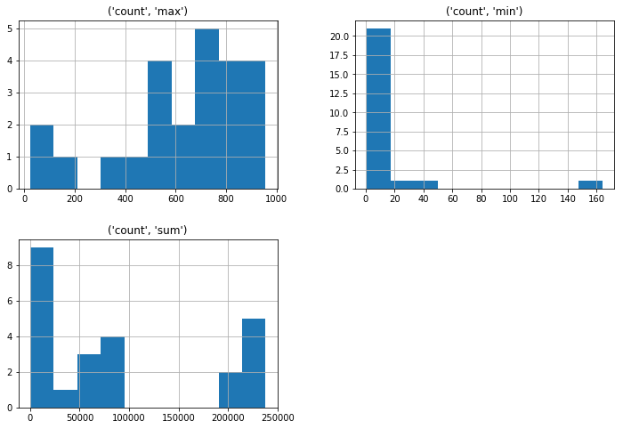

```python
display(pd.DataFrame(raw_train['weather'].value_counts()/raw_train['weather'].value_counts().sum()*100).T)
display(pd.crosstab(index=raw_train['count'], columns=raw_train['weather'], margins=True))
sub_table = pd.crosstab(index=raw_train['count'], columns=raw_train['weather'], margins=True)
display(sub_table/sub_table.loc['All']*100)

display(raw_train.groupby('weather').describe().T)
display(raw_train.groupby(['weather', 'DayofWeek']).describe())
raw_train.groupby(['weather', 'DayofWeek']).count()
display(raw_train.groupby(['weather', 'DayofWeek']).mean())
raw_train.groupby(['weather', 'DayofWeek']).agg({'count':'mean'})
display(raw_train.groupby(['weather', 'DayofWeek']).agg({'count':[sum, min, max]}))
raw_train.groupby(['weather', 'DayofWeek']).agg({'count':[sum, min, max]}).hist(grid=True, figsize=(12,8))

raw_train.groupby('weather').groups.keys()
raw_train.groupby('weather').groups.items()
for key, item in raw_train.groupby('weather'):
#     display(key, item)
    display(raw_train.groupby('weather').get_group(key).head())

pd.cut(raw_train['temp'], 10)
display(pd.cut(raw_train['temp'], 10).value_counts())
display(raw_train.groupby(pd.cut(raw_train['temp'], 10)).describe().T)
```

```
array([[<matplotlib.axes._subplots.AxesSubplot object at 0x0000024A8FC14CF8>,
      dtype=object)
```

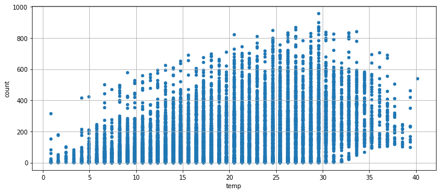

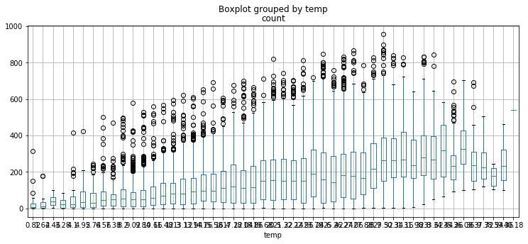

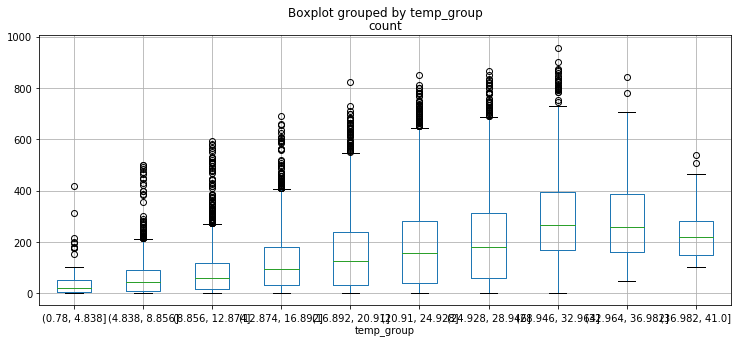

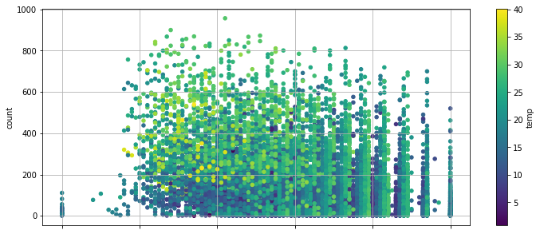

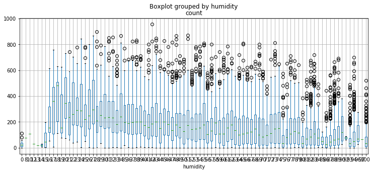

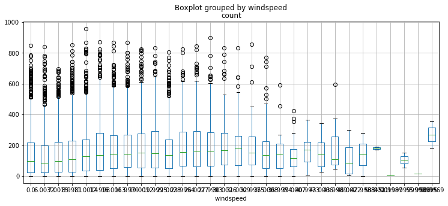

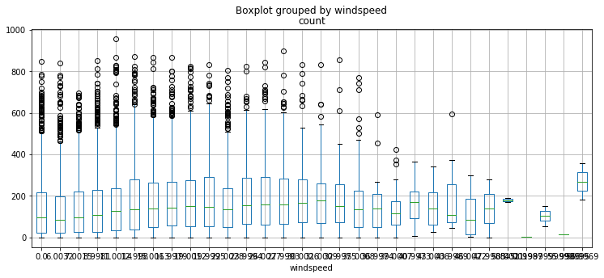

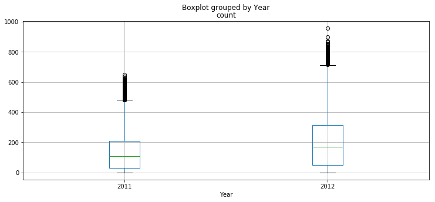

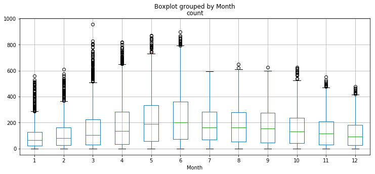

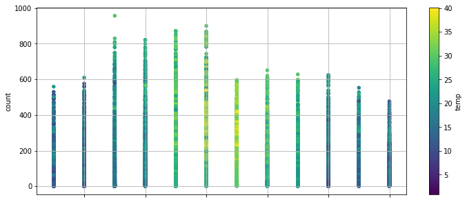

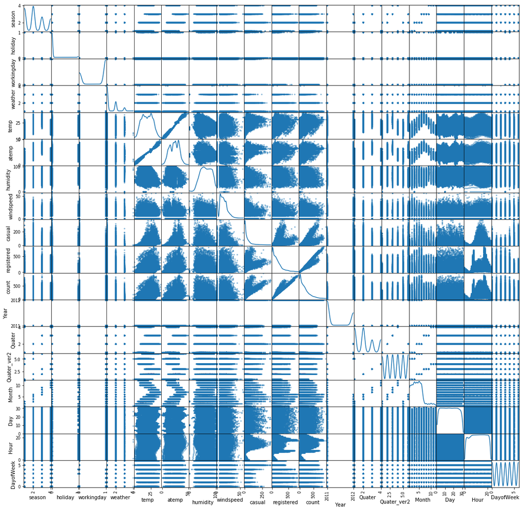

```python
raw_train.plot.scatter(y='count', x='temp', grid=True, figsize=(12,5))
raw_train.boxplot(column='count', by='temp', grid=True, figsize=(12,5))
raw_train.boxplot(column='count', by='temp_group', grid=True, figsize=(12,5))

raw_train.plot.scatter(y='count', x='humidity', c='temp', grid=True, figsize=(12,5), colormap='viridis')
raw_train.boxplot(column='count', by='humidity', grid=True, figsize=(12,5))
raw_train.boxplot(column='count', by='windspeed', grid=True, figsize=(12,5))
raw_train.boxplot(column='count', by='windspeed', grid=True, figsize=(12,5))
raw_train.boxplot(column='count', by='Year', grid=True, figsize=(12,5))
raw_train.boxplot(column='count', by='Month', grid=True, figsize=(12,5))
raw_train.plot.scatter(y='count', x='Month', c='temp', grid=True, figsize=(12,5), colormap='viridis')

pd.plotting.scatter_matrix(raw_train, figsize=(18,18), diagonal='kde')
```